# Network Analysis in R

Dr Mike Spencer, Mr Josh Bird & Dr Elliot Meador

23 March 2018

## Networks: History & Terminology

In this section we will discuss

1. A, very brief, history of network analysis in academic literature
   - Grannovetter (1978) . . . *forbidden tryads*
2. Key terminology needed in discussing network attributes.
   - Measures of centrality
     - Degree
     - Betweeness
     - Closeness

## History

Social networks have been a prominent part of sociological theory since the very beginning.

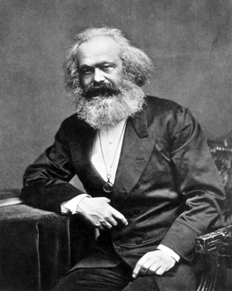

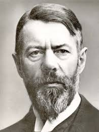

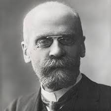

## History

In 1978, Mark Granovetter published his seminal paper, *The Strength of Weak Ties*, which introduced a concise and coherent theory of how information flows in networks.

1. The **Forbidden tryad**

   [*definition*] If two people are connected to the same person, they are inherently connected.

[interactive chart not shown]

## Graph Centrality

It is often helpful to identify key people or nodes in graphs. Specific individuals – such as the company boss – can be specified before hand with prior knowledge.

But, just because an individual is the boss – and in a position of authority, they may not be influential within the network.

Measures of centraility help us better identify key nodes in a network graph.

### An example

Suppose we have a network comprise of all group members in marketing company. This group has 4 team leaders. Looking at the graph below, which member is most closely connected to all others?

[interactive chart not shown]

## Degree

The degree of a graph vertex of a graph is the number of graph edges which touch.

[interactive chart not shown]

## Closeness

Closeness is the sum of the length of the shortest paths between the node and all other nodes in the graph. Thus the more central a node is, the closer it is to all other nodes.

[interactive chart not shown]

## Betweenness

The betweenness centrality for each vertex is the number of these shortest paths that pass through the vertex.

[interactive chart not shown]